# Gam models: summary

# Macrosomia vs “Normal” birthweight

## 2007-2020

```
##
## Family: binomial
## Link function: logit
##
## Formula:
## macro_norm ~ s(GA_weeks) + s(mat_age) + s(birth_Y_M_num) + s(month,
##     bs = "cc") + s(mean_ssep2) + parity_cat + Urban3 + Language +
##     mother_nationality_cat2
##
## Parametric coefficients:
##                                                       Estimate Std. Error  z value Pr(>|z|)
## (Intercept)                                          -2.987102   0.008460 -353.095  < 2e-16 ***
## parity_cat(1,2]                                       0.582783   0.008308   70.148  < 2e-16 ***
## parity_cat(2,3]                                       0.842082   0.011438   73.619  < 2e-16 ***
## parity_cat(3,20]                                      0.988156   0.018277   54.064  < 2e-16 ***
## Urban3                                                0.013789   0.007672    1.797  0.07230 .
## LanguageFrench                                       -0.268640   0.009402  -28.572  < 2e-16 ***
## LanguageItalian                                      -0.372856   0.023038  -16.184  < 2e-16 ***
## mother_nationality_cat2Africa                         0.061701   0.021283    2.899  0.00374 **
## mother_nationality_cat2Asia                          -0.109184   0.022228   -4.912 9.01e-07 ***
## mother_nationality_cat2Europe                         0.172047   0.008118   21.193  < 2e-16 ***
## mother_nationality_cat2Northern America               0.337517   0.043411    7.775 7.55e-15 ***
## mother_nationality_cat2Southern and Central America   0.148848   0.028587    5.207 1.92e-07 ***
## ---
## Signif. codes:  0 '***' 0.001 '**' 0.01 '*' 0.05 '.' 0.1 ' ' 1
##
## Approximate significance of smooth terms:
##                    edf Ref.df    Chi.sq p-value
## s(GA_weeks)      7.583  8.265 30379.847  <2e-16 ***
## s(mat_age)       4.546  5.477    12.711  0.0357 *
## s(birth_Y_M_num) 4.311  5.306    77.786  <2e-16 ***
## s(month)         2.004  8.000     7.625  0.0102 *
## s(mean_ssep2)    6.649  7.794    57.513  <2e-16 ***
## ---
## Signif. codes:  0 '***' 0.001 '**' 0.01 '*' 0.05 '.' 0.1 ' ' 1
##
## R-sq.(adj) =  0.0445   Deviance explained = 7.43%
## fREML = 1.4871e+06  Scale est. = 1         n = 1049183
```

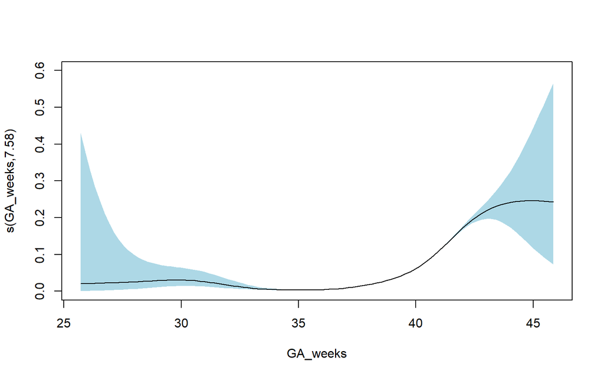

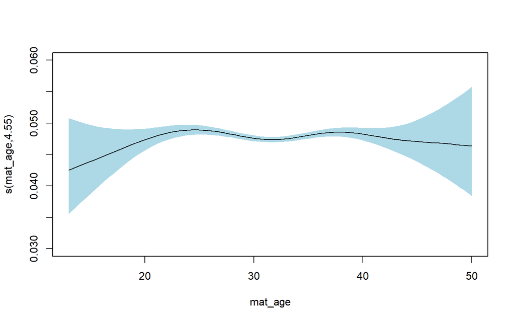

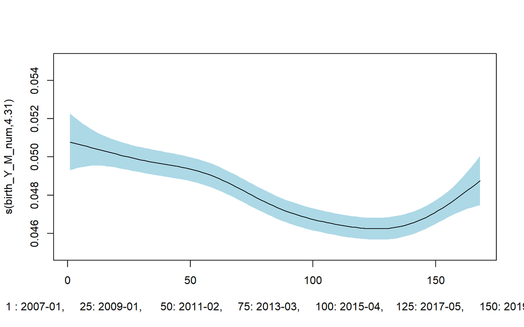

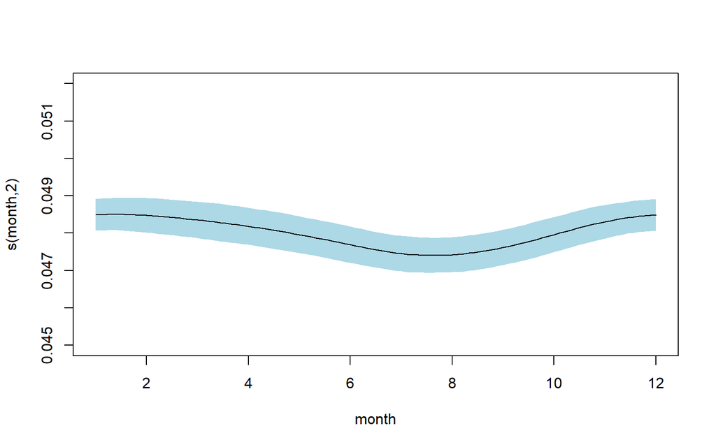

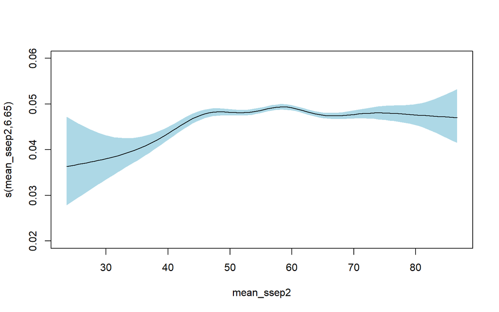

```
##                                                         OR  lci      uci    d
## (Intercept)                                           0.05 0.05     0.05 1.65
## parity_cat(1,2]                                       1.79 1.76     1.82 0.32
## parity_cat(2,3]                                       2.32 2.27     2.37 0.47
## parity_cat(3,20]                                      2.69 2.59     2.78 0.55
## Urban3                                                1.01 1.00     1.03 0.01
## LanguageFrench                                        0.76 0.75     0.78 0.15
## LanguageItalian                                       0.69 0.66     0.72 0.21
## mother_nationality_cat2Africa                         1.06 1.02     1.11 0.03
## mother_nationality_cat2Asia                           0.90 0.86     0.94 0.06
## mother_nationality_cat2Europe                         1.19 1.17     1.21 0.10
## mother_nationality_cat2Northern America               1.40 1.29     1.53 0.19
## mother_nationality_cat2Southern and Central America   1.16 1.10     1.23 0.08
## s(GA_weeks).1                                        14.40 0.01 17322.53 1.47
```

## 2017-2020

```
##
## Family: binomial
## Link function: logit
##
## Formula:
## macro_norm ~ s(GA_weeks) + s(mat_age) + s(birth_Y_M_num) + s(mean_ssep2) +
##     parity_cat + Urban3 + Language + mother_nationality_cat2
##
## Parametric coefficients:
##                                                       Estimate Std. Error  z value Pr(>|z|)
## (Intercept)                                          -2.956880   0.015290 -193.391  < 2e-16 ***
## parity_cat(1,2]                                       0.615493   0.015115   40.721  < 2e-16 ***
## parity_cat(2,3]                                       0.875919   0.020721   42.272  < 2e-16 ***
## parity_cat(3,20]                                      1.019358   0.033449   30.475  < 2e-16 ***
## Urban3                                                0.005767   0.013886    0.415  0.67793
## LanguageFrench                                       -0.290059   0.016787  -17.279  < 2e-16 ***
## LanguageItalian                                      -0.421548   0.045139   -9.339  < 2e-16 ***
## mother_nationality_cat2Africa                        -0.051788   0.035678   -1.452  0.14663
## mother_nationality_cat2Asia                          -0.105310   0.038140   -2.761  0.00576 **
## mother_nationality_cat2Europe                         0.130847   0.014712    8.894  < 2e-16 ***
## mother_nationality_cat2Northern America               0.299688   0.083080    3.607  0.00031 ***
## mother_nationality_cat2Southern and Central America   0.116058   0.056445    2.056  0.03977 *
## ---
## Signif. codes:  0 '***' 0.001 '**' 0.01 '*' 0.05 '.' 0.1 ' ' 1
##
## Approximate significance of smooth terms:
##                    edf Ref.df  Chi.sq  p-value
## s(GA_weeks)      6.042  6.861 8858.18  < 2e-16 ***
## s(mat_age)       3.941  4.844   18.78  0.00153 **
## s(birth_Y_M_num) 2.447  3.048   12.79  0.00532 **
## s(mean_ssep2)    4.471  5.570   41.54 1.57e-06 ***
## ---
## Signif. codes:  0 '***' 0.001 '**' 0.01 '*' 0.05 '.' 0.1 ' ' 1
##
## R-sq.(adj) =  0.043   Deviance explained = 7.15%
## fREML = 4.5085e+05  Scale est. = 1         n = 318002
```

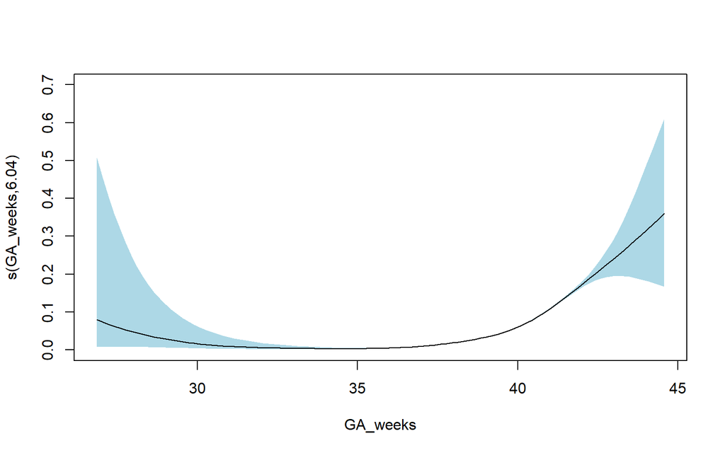

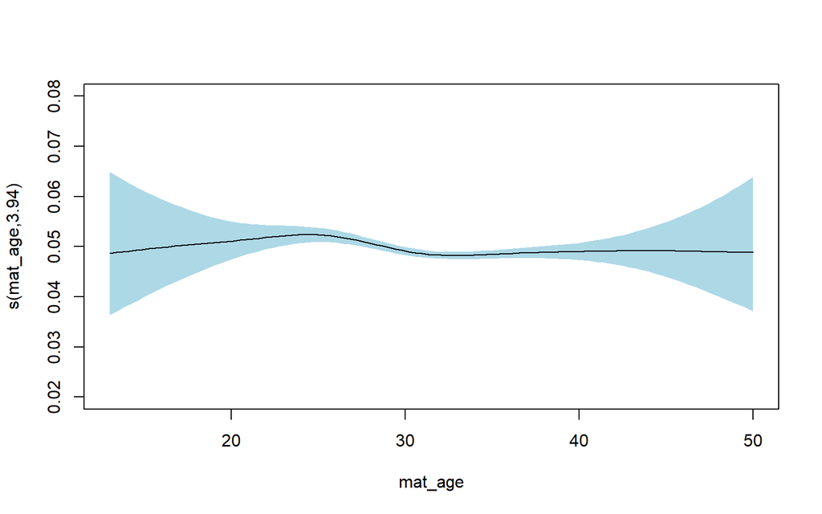

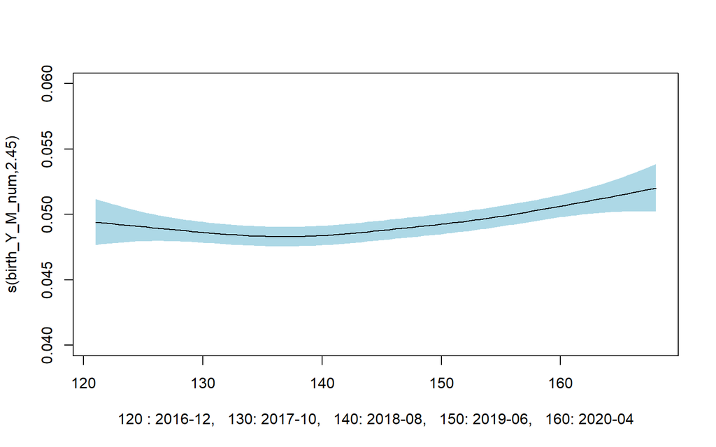

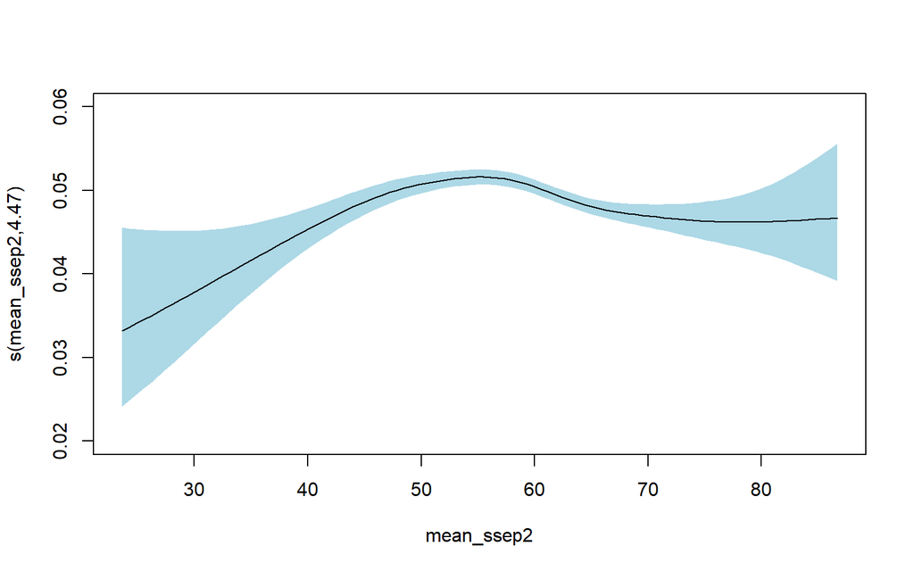

```
##                                                        OR  lci   uci    d
## (Intercept)                                          0.05 0.05  0.05 1.63
## parity_cat(1,2]                                      1.85 1.80  1.91 0.34
## parity_cat(2,3]                                      2.40 2.31  2.50 0.48
## parity_cat(3,20]                                     2.77 2.60  2.96 0.56
## Urban3                                               1.01 0.98  1.03 0.00
## LanguageFrench                                       0.75 0.72  0.77 0.16
## LanguageItalian                                      0.66 0.60  0.72 0.23
## mother_nationality_cat2Africa                        0.95 0.89  1.02 0.03
## mother_nationality_cat2Asia                          0.90 0.84  0.97 0.06
## mother_nationality_cat2Europe                        1.14 1.11  1.17 0.07
## mother_nationality_cat2Northern America              1.35 1.15  1.59 0.17
## mother_nationality_cat2Southern and Central America  1.12 1.01  1.25 0.06
## s(GA_weeks).1                                        0.30 0.00 63.35 0.66
```

# Discussion

Crises details to be added:  
- COVID data will be included : hospital cases and mortality  
- 2008/09 economic crisis: inclusion of a more “detailed” timing: Q4 2008 and Q1 2009 (Prof. Tobias Straumann, economic historian at UZH specialized in recent economic crises. Same timing from the changes in GDP per trimester on ([seco website](https://www.seco.admin.ch/seco/en/home/wirtschaftslage---wirtschaftspolitik/Wirtschaftslage/bip-quartalsschaetzungen-/daten.html))  
- influenza pandemic 2009/2010  
- heat waves 2015 and 2018

- Spatial analysis will be added: were there specific areas in Switzerland, maybe more affected by COVID-19, where there were specific changes in birthweight?